# Lecture 10 - Multiple Regression

Bill Perry

# Lecture 09: Review

Covered

- Regression T-Test Anova
- Regression Assumptions
- sum of squared allocation and subdivision from total sums of squares

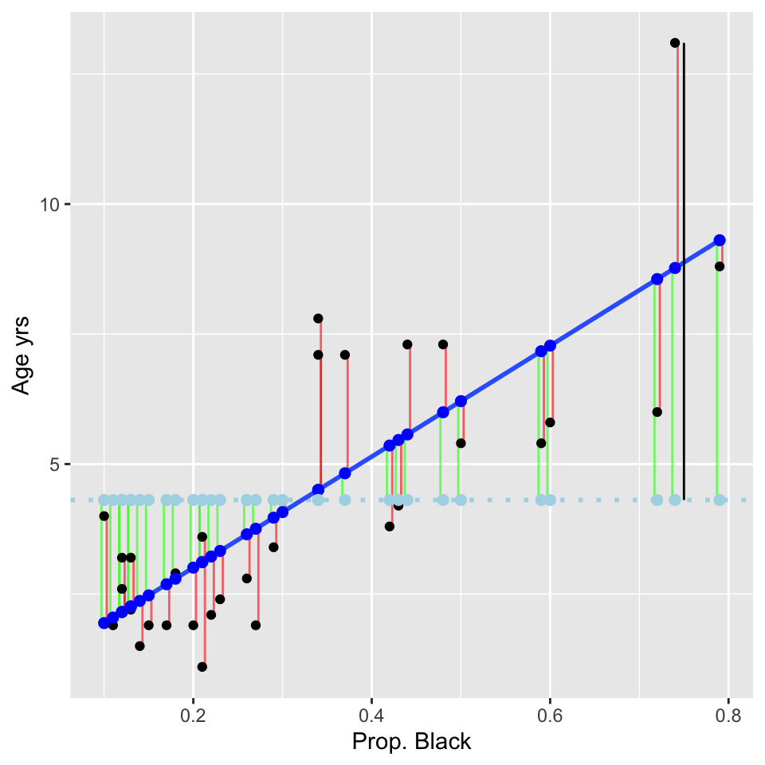

# Lecture 10: Overview

Multiple Linear Regression model

- Regression parameters
- Analysis of variance
- Null hypotheses
- Explained variance
- Assumptions and diagnostics
- Collinearity
- Interactions
- Dummy variables
- Model selection
- Importance of predictors

# **Lecture 10:** Analyses

What if more than one predictor (X) variable?

- If predictors continuous
- Mix between categorical and continuous
- Can use multiple linear regression

|  | Independent variable |  |
| --- | --- | --- |
| **Dependent variable** | **Continuous** | **Categorical** |
| **Continuous** | Regression | ANOVA |
| **Categorical** | Logistic regression |  |

# **Lecture 10:** Analyses

Abundance of ants can be modeled as function of

- latitude
- longitude
- both

Instead of line, modeled with (hyper)plane

[interactive chart not shown]

# **Lecture 10:** Analyses

Used in similar way to simple linear regression:

- Describe nature of relationship between Y and X’s
- Determine explained / unexplained variation in Y
- Predict new Ys from X
- Find the “best” model

[interactive chart not shown]

# **Lecture 10:** Analyses

Crawley 2012: “Multiple regression models provide some of the most profound challenges faced by the analyst”:

- Overfitting
- Parameter proliferation
- Multicollinearity
- Model selection

[figure not shown]

# **Lecture 10:** Analyses

Multiple Regression:

- Set of i= 1 to n observations
- fixed X-values for p predictor variables (X1, X2…Xp)
- random Y-values:

$$y_i = \beta_0 + \beta_1 x_{i1} + \beta_2 x_{i2} + ... + \beta_p x_{ip} + \epsilon_i$$

- y<sub>i</sub>: value of Y for i<sup>th</sup> observation X<sub>1</sub> = x<sub>i1</sub>, X<sub>2</sub> = x<sub>i2</sub>,…, x<sub>p</sub> = x<sub>ip</sub>
- β<sub>0</sub>: population intercept, the mean value of Y when X<sub>1</sub>= 0, X<sub>2</sub> = 0,…, X<sub>p</sub> = 0

# **Lecture 10:** Multiple linear regression model

Multiple Regression:

$$y_i = \beta_0 + \beta_1 x_{i1} + \beta_2 x_{i2} + ... + \beta_p x_{ip} + \epsilon_i$$

- β<sub>1</sub>: partial regression slope, change in Y per unit change in X<sub>1</sub> holding other X-vars constant
- β<sub>2</sub>: partial regression slope, change in Y per unit change in X<sub>2</sub> holding other X-vars constant
- β<sub>p</sub>: partial regression slope, change in Y per unit change in X<sub>p</sub> holding other X-vars constant

What is partial - the relationship between a predictor variable and the response variable **while holding all other predictor variables constant**. It tells you the isolated effect of one variable, controlling for the influence of others.

# Lecture 10: Partial regression slopes

model: ant_spp ~ elevation + latitude

- The partial slope for elevation tells you how ant species richness changes with elevation when latitude is held constant
  - 1-m increase in elevation - ant spp decrease by 0.012 spp, holding latitude constant
  - Or 100-meter increase in elevation, lose 1.2 spp
- The partial slope for latitude tells you how ant species richness changes with latitude when elevation is held constant
  - 1-degree increase in latitude, ant spp decrease by 2 species, holding elevation constant
  - Moving north = fewer ant spp, even when comparing sites at same elevation

```r
model <- lm(ant_spp ~ elevation + latitude, data = ant_df)
summary(model)
```

```
Call:
lm(formula = ant_spp ~ elevation + latitude, data = ant_df)

Residuals:
    Min      1Q  Median      3Q     Max
-6.1180 -2.3759  0.3218  1.9070  5.8369

Coefficients:
            Estimate Std. Error t value Pr(>|t|)
(Intercept) 98.49651   26.50701   3.716  0.00147 **
elevation   -0.01226    0.00411  -2.983  0.00765 **
latitude    -2.00981    0.61956  -3.244  0.00427 **
---
Signif. codes:  0 '***' 0.001 '**' 0.01 '*' 0.05 '.' 0.1 ' ' 1

Residual standard error: 3.022 on 19 degrees of freedom
Multiple R-squared:  0.5543,    Adjusted R-squared:  0.5074
F-statistic: 11.82 on 2 and 19 DF,  p-value: 0.000463
```

# **Lecture 10:** Regression parameters

Multiple Regression:

$$y_i = \beta_0 + \beta_1 x_{i1} + \beta_2 x_{i2} + ... + \beta_p x_{ip} + \epsilon_i$$

- ε<sub>i</sub>: unexplained error - difference between y<sub>i</sub> and value predicted by model (ŷ<sub>i</sub>)
- ant_spp = β<sub>0</sub> + β<sub>1</sub>(lat) + β<sub>2</sub>(elevation) + ε<sub>i</sub>

# **Lecture 10:** Regression parameters

Multiple Regression:

$$y_i = \beta_0 + \beta_1 x_{i1} + \beta_2 x_{i2} + ... + \beta_p x_{ip} + \epsilon_i$$

- Estimate multiple regression parameters (intercept, partial slopes) using OLS to fit the regression line
- OLS minimize ∑(y<sub>i</sub>-ŷ<sub>i</sub>)<sup>2</sup>, the SS (vertical distance) between observed y<sub>i</sub> and predicted ŷ<sub>i</sub> for each x<sub>ij</sub>
- ε estimated as residuals: ε<sub>i</sub> = y<sub>i</sub>-ŷ<sub>i</sub>
- Calculation solves set of simultaneous normal equations with matrix algebra

# **Lecture 10:** Regression parameters

Regression equation can be used for prediction by subbing new values for predictor (X) variables

- Confidence intervals calculated for parameters
- Confidence and prediction intervals depend on number of observations and number of predictors
  - More observations decrease interval width
  - More predictors increase interval width
- Prediction should be restricted to within range of X variables

# **Lecture 10:** Analyses of variance or sums of squares

Variance - SS<sub>total</sub> partitioned into SS<sub>regression</sub> and SS<sub>residual</sub>

- SS<sub>regression</sub> is variance in Y explained by model
- SS<sub>residual</sub> is variance not explained by model

| Source of variation | SS | df | MS | Interpretation |
| --- | --- | --- | --- | --- |
| Regression | $\sum_{i=1}^{n} (y_i - \bar{y})^2$ | $p$ | $\frac{\sum_{i=1}^{n} (y_i - \bar{y})^2}{p}$ | Difference between predicted observation and mean |
| Residual | $\sum_{i=1}^{n} (y_i - \hat{y}_i)^2$ | $n-p-1$ | $\frac{\sum_{i=1}^{n} (y_i - \hat{y}_i)^2}{n-p-1}$ | Difference between each observation and predicted |
| Total | $\sum_{i=1}^{n} (y_i - \bar{y})^2$ | $n-1$ |  | Difference between each observation and mean |

# **Lecture 10:** Analyses

### SS converted to non-additive MS=(SS/df)

- MS<sub>residual</sub>: estimate population variance
- MS<sub>regression</sub>: estimate population variance + variation due to strength of X-Y relationships
- MS is an estimate of variance that doesn’t increase with sample size the way Sum of Squares (SS) does

| Source of variation | SS | df | MS |
| --- | --- | --- | --- |
| Regression | $\sum_{i=1}^{n} (y_i - \bar{y})^2$ | $p$ | $\frac{\sum_{i=1}^{n} (y_i - \bar{y})^2}{p}$ |
| Residual | $\sum_{i=1}^{n} (y_i - \hat{y}_i)^2$ | $n-p-1$ | $\frac{\sum_{i=1}^{n} (y_i - \hat{y}_i)^2}{n-p-1}$ |
| Total | $\sum_{i=1}^{n} (y_i - \bar{y})^2$ | $n-1$ |  |

# **Lecture 10:** Hypotheses

### Two Null Hypotheses usually tested in MLR:

- “Basic” H<sub>o</sub>: all partial regression slopes equal 0; β<sub>1</sub> = β<sub>2</sub> = … = β<sub>p</sub> = 0
- If “basic” H<sub>o</sub> true, MS<sub>regression</sub> and MS<sub>residual</sub> estimate variance and their ratio (F-ratio) = 1
- If “basic” H<sub>o</sub> false (at least one β ≠ 0) MS<sub>regression</sub> estimates variance + partial regression slope and their ratio (F-ratio) will be > 1 - F-ratio compared to F-distribution for p-value

# **Lecture 10:** Hypotheses

### Also: is any specific β = 0 (explanatory role)?

- E.g., does LAT have effect on Ant species?
- These H’s tested through model comparison
- Model 1 - model with 2 predictors X<sub>1</sub>, X<sub>2</sub>:
  - yi= β<sub>0</sub> +β<sub>1</sub>x<sub>i1</sub>+β<sub>2</sub>x<sub>i2</sub>+ ε<sub>i</sub>
- Model 2 - To test H<sub>o</sub> that β<sub>2</sub> = 0 compare fit of **model 1** to **model 2** with 1 predictor:
  - y<sub>i</sub>= β<sub>0</sub> +β<sub>1</sub>x<sub>i1</sub>+ ε<sub>i</sub>

# **Lecture 10:** Hypotheses

- If SS<sub>regression</sub> of model<sub>1</sub>=model<sub>2</sub>, cannot reject H<sub>o</sub> β<sub>1</sub> = 0
  - adding X<sub>2</sub> did not explain any additional variance
- If SS<sub>regression</sub> of mod1 > mod2, evidence to reject H<sub>o</sub> β<sub>1</sub> = 0
  - adding X2 explains more variance
  - evidence to reject H0: β<sub>2</sub> = 2
- SS for β<sub>1</sub> is SS<sub>extra</sub>β<sub>1</sub> = Full SS<sub>regression</sub> - Reduced SS<sub>regression</sub>
  - This quantifies how much additional variance X<sub>2</sub> explains
- Use partial F-test to test Ho β<sub>1</sub> = 0 :

$$F_{w,n-p} = \frac{MS_{Extra}}{FULL\ MS_{Residual}}$$
**Can also use t-test (R provides this value)**

# **Lecture 10:** Explained variance

Explained variance (r<sup>2</sup>) is calculated the same way as for simple regression:

$$r^2 = \frac{SS_{Regression}}{SS_{Total}} = 1 - \frac{SS_{Residual}}{SS_{Total}}$$

- r<sup>2</sup> values can not be used to directly compare models
- r<sup>2</sup> values will always increase as predictors added
- r<sup>2</sup> values with different transformation will differ

# **Lecture 10:** Assumptions and diagnostics

- Assume fixed Xs; unrealistic in most biological settings
- No major (influential) outliers
- Check leverage, influence- Cook’s Di

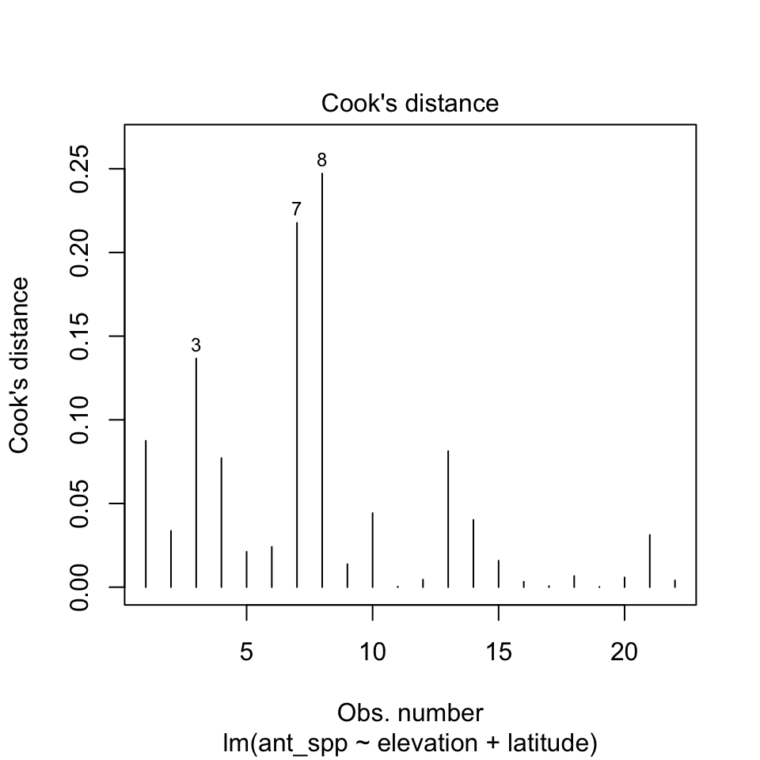

```r
# Plot Cook's distance
plot(model, which = 4)
```

# **Lecture 10:** Assumptions and diagnostics

- Normality, equal variance, independence
- Residual QQ-plots, residuals vs. predicted values plot
- Distribution/variance often corrected by transforming Y

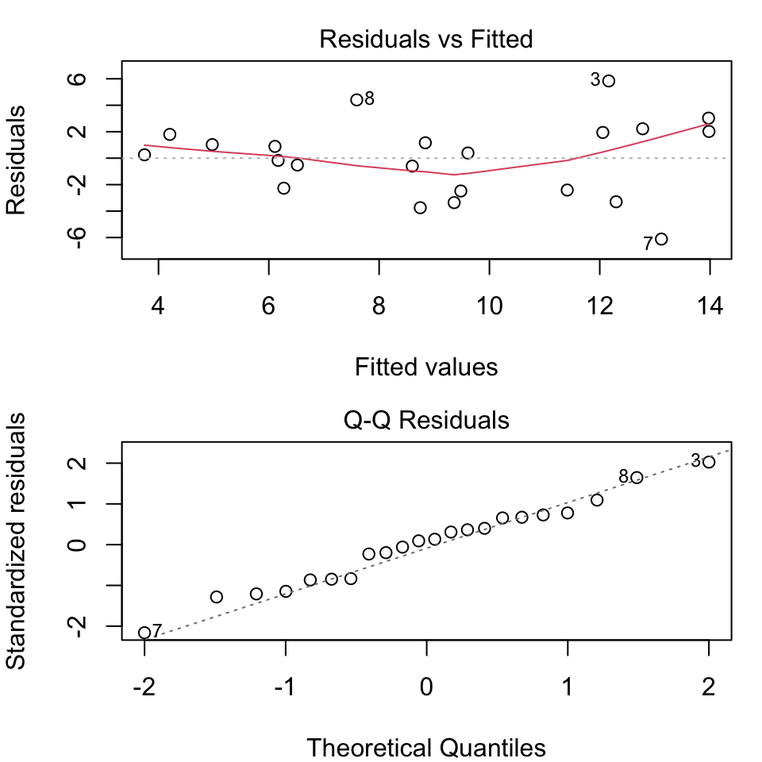

# **Lecture 10:** Assumptions and diagnostics

- **More observations than predictor variables**
  - Ideally **at least 10x observations than predictors** to avoid “overfitting” **10:1**
    - 2 predictors = 20 observations!!!
- **No colinearity**
  - **Need Uncorrelated predictor variables (assessed using scatterplot matrix; VIFs)**
- **Each X has linear relationship with Y after accounting for other predictors**
  - **Added Variable (AV) plots** (also called partial regression plots)
    - These show the relationship between Y and X₁ after removing the linear effects of all other predictors
    - Create AV plots for all predictors - `avPlots(model)`
    - Or for just one predictor - `avPlot(model, variable = "proportion_black")`

# **Lecture 10:** Analyses

Regression of Y vs. each X does not consider effect of other predictors:

want to know shape of relationship while holding other predictors constant

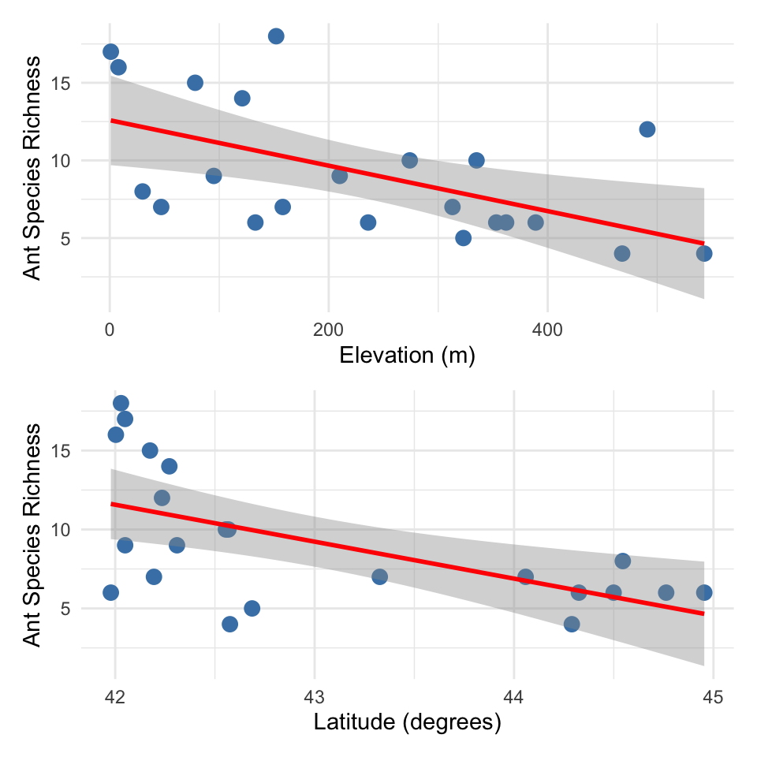

# **Lecture 10:** Collinearity

- Potential predictor variables are often correlated (e.g., morphometrics, nutrients, climatic parameters)
- Multicollinearity (strong correlation between predictors) causes problems for parameter estimates
- Severe collinearity causes unstable parameter estimates: small change in a single value can result in large changes in βp - estimates
- Inflates partial slope error estimates, loss of power

```
           elevation   latitude    ant_spp
elevation  1.0000000  0.1787454 -0.5545244
latitude   0.1787454  1.0000000 -0.5879407
ant_spp   -0.5545244 -0.5879407  1.0000000
```

# **Lecture 10:** Collinearity

### Collinearity can be detected by:

- Variance inflation Factors **(VIF)**:
  - VIF for X<sub>j</sub>=1/ (1-r<sup>2</sup> )
  - VIF > 10 = bad
- Best/simplest solution:
  - exclude variables that are highly correlated with other variables
  - they are probably measuring similar things and are redundant

# **Lecture 10:** Interactions

### Predictors can be modeled as:

- **additive (effect of temp, plus precip, plus fertility) or**
- **multiplicative (interactive)**
- **Interaction: effect of Xi depends on levels of Xj**
- The partial slope of Y vs. X<sub>1</sub> is different for different levels of X<sub>2</sub> (and vice versa); measured by β<sub>3</sub>

$$y_i = \beta_0 + \beta_1X_{i1} + \beta_2X_{i2} + \epsilon_i \quad \text{vs.} \quad y_i = \beta_0 + \beta_1X_{i1} + \beta_2X_{i2} + \beta_3X_{i1}*X_{i2} \epsilon_i$$

This leads to “Curvature” of the regression (hyper)plane

# **Lecture 10:** Analyses

Interaction terms lead to “Curvature” of the regression (hyper)plane

[interactive chart not shown]

# **Lecture 10:** Analyses

Adding interactions:

- many more predictors (“parameter proliferation”):
- 2<sup>n</sup> is required; 6 parameters = 64 terms; 7 parameters= 128
- interpretation more complex
- When to include interactions? When they make biological sense!!!

# **Lecture 10:** Dummy variables

**Multiple Linear Regression accommodates continuous and categorical variables** (gender, vegetation type, etc.) Categorical vars as “dummy vars”, n of dummy variables = n-1 categories

- **Sex M/F:**
  - Need 1 dummy var with two values (0, 1)
- **Fertility L/M/H:**
  - Need 2 dummy var, each with two values (0, 1): fert1 (0 if L or H, 1 if M), fert2 (1 if H, 0 if L or M)

| Fertility | fert1 | fert2 |
| --- | --- | --- |
| Low | 0 | 0 |
| Med | 1 | 0 |
| High | 0 | 1 |

# **Lecture 10:** Analyses

### Coefficients interpreted relative to reference condition

- R codes dummy variables automatically
- picks “reference” level alphabetically
- Dummy variables with more than 2 levels add extra predictor variables to model

| Fertility | fert1 | fert2 |
| --- | --- | --- |
| Low | 0 | 0 |
| Med | 1 | 0 |
| High | 0 | 1 |

# **Lecture 10:** Analyses

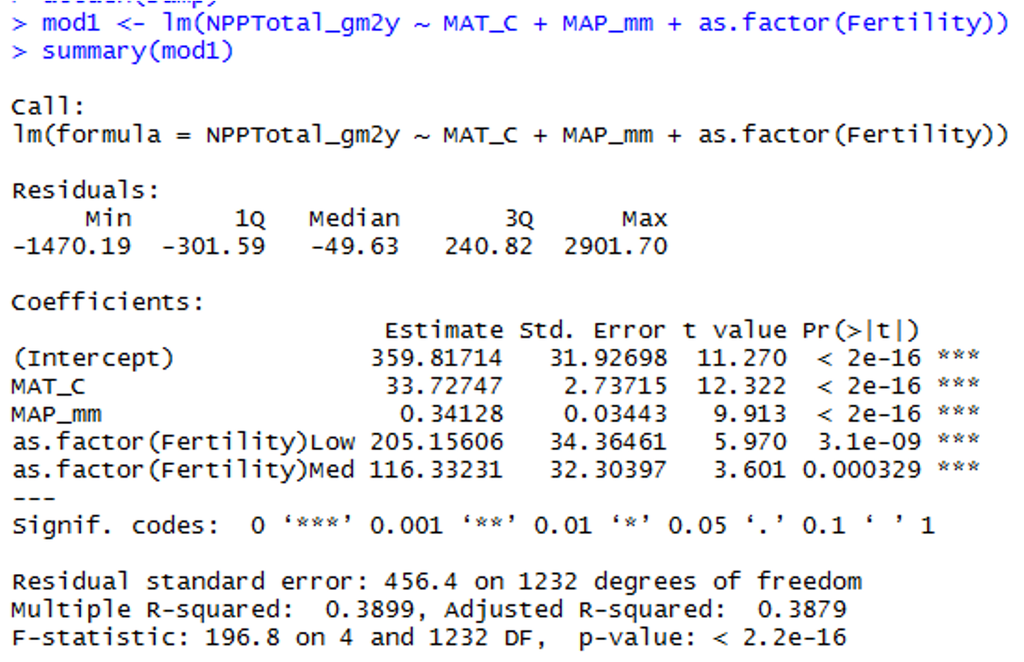

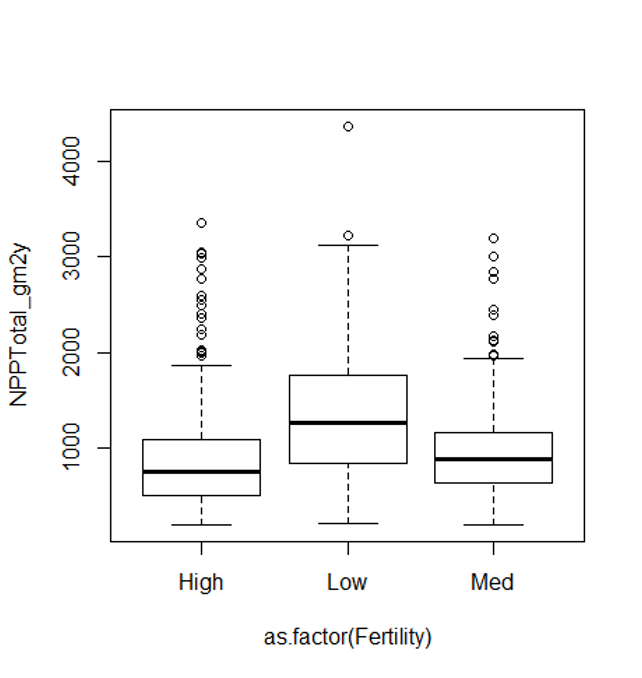

# **Lecture 10:** Comparing models

- When have multiple predictors (and interactions!)
  - how to choose “best” model?
  - Which predictors to include?
  - Occam’s razor: “best” model balances complexity with fit to data
- To chose:
  - compare “nested” models
- Overfitting
  - getting high r2 just by having more (useless predictors)
  - so r2 is not a good way of choosing between nested models

# **Lecture 10:** Comparing models

### Need to account for increase in fit with added predictors:

- Adjusted r2
- Akaike’s information criterion (AIC)
- Both “penalize” models for extra predictors
- Higher adjusted r2 and lower AIC are better when comparing models
  - p = predictors
  - n = #

$$\text{Adjusted } r^2 = 1 - \frac{SS_{\text{Residual}}/(n - (p + 1))}{SS_{\text{Total}}/(n - 1)}$$
$$\text{Akaike Information Criterion (AIC)} = n[\ln(SS_{\text{Residual}})] + 2(p + 1) - n\ln(n)$$

# **Lecture 10:** Comparing models

- But how to compare models?
  - Can fit all possible models
    - compare AICs or adj- r2,
    - tedious w lots of predictors
  - Automated forward (and backward) stepwise procedures: start w no terms (all terms), add (remove) terms w largest (smallest)
    - partial F statistic
- We will use manual form of backward selection

# **Lecture 10:** Analyses

```
========== FULL MODEL (Both Variables) ==========
```

```
Call:
lm(formula = ant_spp ~ elevation + latitude, data = ant_df)

Residuals:
    Min      1Q  Median      3Q     Max
-6.1180 -2.3759  0.3218  1.9070  5.8369

Coefficients:
            Estimate Std. Error t value Pr(>|t|)
(Intercept) 98.49651   26.50701   3.716  0.00147 **
elevation   -0.01226    0.00411  -2.983  0.00765 **
latitude    -2.00981    0.61956  -3.244  0.00427 **
---
Signif. codes:  0 '***' 0.001 '**' 0.01 '*' 0.05 '.' 0.1 ' ' 1

Residual standard error: 3.022 on 19 degrees of freedom
Multiple R-squared:  0.5543,    Adjusted R-squared:  0.5074
F-statistic: 11.82 on 2 and 19 DF,  p-value: 0.000463
```

# **Lecture 10:** Analyses

```
========== ELEVATION ONLY MODEL ==========
```

```
Call:
lm(formula = ant_spp ~ elevation, data = ant_df)

Residuals:
    Min      1Q  Median      3Q     Max
-4.9010 -2.6947 -0.9502  2.9657  7.6363

Coefficients:
             Estimate Std. Error t value Pr(>|t|)
(Intercept) 12.589088   1.385615   9.086 1.55e-08 ***
elevation   -0.014641   0.004913  -2.980   0.0074 **
---
Signif. codes:  0 '***' 0.001 '**' 0.01 '*' 0.05 '.' 0.1 ' ' 1

Residual standard error: 3.671 on 20 degrees of freedom
Multiple R-squared:  0.3075,    Adjusted R-squared:  0.2729
F-statistic: 8.881 on 1 and 20 DF,  p-value: 0.0074
```

# **Lecture 10:** Analyses

```
========== LATITUDE ONLY MODEL ==========
```

```
Call:
lm(formula = ant_spp ~ latitude, data = ant_df)

Residuals:
    Min      1Q  Median      3Q     Max
-6.2223 -2.1188  0.0599  2.1267  6.4990

Coefficients:
            Estimate Std. Error t value Pr(>|t|)
(Intercept) 109.8532    30.9803   3.546  0.00203 **
latitude     -2.3401     0.7199  -3.251  0.00401 **
---
Signif. codes:  0 '***' 0.001 '**' 0.01 '*' 0.05 '.' 0.1 ' ' 1

Residual standard error: 3.569 on 20 degrees of freedom
Multiple R-squared:  0.3457,    Adjusted R-squared:  0.313
F-statistic: 10.57 on 1 and 20 DF,  p-value: 0.004006
```

# **Lecture 10:** Analyses

```
========== MODEL COMPARISON TABLE ==========
```

```
           Model Adjusted_R2      AIC R2_vs_Full AIC_vs_Full
1 Both Variables   0.5074180 115.8646  0.0000000    0.000000
2 Elevation Only   0.2728722 123.5608 -0.2345459    7.696164
3  Latitude Only   0.3129580 122.3132 -0.1944600    6.448613
```

```
========== KEY FINDINGS ==========
```

```
Full Model AIC: 115.86 (Adjusted R²: 0.5074)
```

```
Elevation Only AIC: 123.56 (Adjusted R²: 0.2729)
```

```
Latitude Only AIC: 122.31 (Adjusted R²: 0.3130)
```

```
--- Differences from Full Model ---
```

```
Removing latitude: AIC increases by 7.70, Adj R² decreases by -0.2345
```

```
Removing elevation: AIC increases by 6.45, Adj R² decreases by -0.1945
```

```
========== CONCLUSION ==========
```

```
✓ Full model has LOWEST AIC (best fit)
```

```
✓ Full model has HIGHEST Adjusted R² (explains most variance)
```

```
✗ Removing either variable worsens model performance
```

```
Both elevation and latitude are important predictors of ant species diversity!
```

# **Lecture 10:** Predictors

Usually want to know relative importance of predictors to explaining Y

- Three general approaches:
- Using F-tests (or t-tests) on partial regression slopes
- Using coefficient of partial determination
- Using standardized partial regression slopes

# **Lecture 10:** Predictors

Using F-tests (or t-tests) on partial regression slopes:

- Conduct F tests of Ho that each partial regression slope = 0
- If cannot reject Ho, discard predictor
- Can get additional clues from relative size of F-values
- Does not tell us absolute importance of predictor (usually can not directly compare slope parameters)

# **Lecture 10:** Predictors

Using coefficient of partial determination:

- the reduction in variation of Y due to addition of predictor (Xj)

$$r_{X_j}^2 = \frac{SS_{\text{Extra}}}{\text{Reduced }SS_{\text{Residual}}}$$

SSextra

- Increased in SSregression when Xj is added to model
- Reduced SSresidual is the unexplained SS from model without Xj

# **Lecture 10:** Predictors

### Using standardized partial regression slopes:

- predictors of predictor variables can not be directly compared
- Why?
  - Standardize all vars (mean = 0, sd= 1)
  - Scales are identical and larger PRS mean more important variable

# **Lecture 10:** Predictors

- Using partial r<sup>2</sup> values
  - **pEta_sqr (Partial Eta Squared):**
    - **Elevation: 0.3189 (31.9%)** - Elevation explains 31.9% of the variance *after controlling for latitude*
    - **Latitude: 0.3564 (35.6%)** - Latitude explains 35.6% of the variance *after controlling for elevation*
    - Both are important predictors! Latitude is slightly stronger
- dR_sqr (Delta R Squared / Semi-partial R²):
  - Elevation: 0.2087 (20.9%)
    - If you removed elevation from the model, R² would drop by 20.9%
  - Latitude: 0.2468 (24.7%)
  - If you removed latitude from the model, R² would drop by 24.7%
- Shows the unique contribution of each predictor to the total variance explained

```
== Method 2: Type II ANOVA (car package) ==
```

```
Anova Table (Type II tests)

Response: ant_spp
           Sum Sq Df F value   Pr(>F)
elevation  81.224  1  8.8955 0.007652 **
latitude   96.085  1 10.5231 0.004272 **
Residuals 173.487 19
---
Signif. codes:  0 '***' 0.001 '**' 0.01 '*' 0.05 '.' 0.1 ' ' 1
```

```
== Coefficients Table ==
```

```
 Coefficients    SSR df pEta_sqr dR_sqr
    elevation  81.22  1   0.3189 0.2087
     latitude  96.09  1   0.3564 0.2468
    Residuals 173.49 19   0.5000 0.4457
```

```
== Summary Statistics ==
```

```
Sum of squared errors (SSE): 173.5
```

```
Sum of squared total (SST): 389.3
```

```
Model R²: 0.5543
```